# Lab One: Exploring Table Data

#### By: David Hoffman, Jonas Moros, and Sully Billingsley

## 1. Business Understanding

Bitcoin is the longest running and most well-known cryptocurrency on the market. This dataset is comprised of minute to minute updates of OHLC (Open, High, Low, Close), Volume in BTC and indicated currency, and weighted bitcoin price from the period of January 2012 to March of 2021. The first collumn of each row contains a Unix timestamp which represents when the remainder of the datapoints in that row were collected.

This data was collected in order to understand various trends within the Bitcoin market and is used by many traders to train the machine learning algorithms that they use to automate the entirety of their daily crypocurrency trading. Similarly to these cryptocurrency day traders, our prediction task is to predict whether or not the price of bitcoin will rise or fall on any given day.

If we are able to generate a meaningful conclusion from this data the results we obtain could prove incredibly useful for nearly any third party from large public corporations to small private investors. Given the ease with which Bitcoin can be traded on public markets such as Coinbase or Robinhood, anyone who has access to these applications could use our conclusions to guide their bitcoin trades in a profitable direction.

In order for our research to be useful for our needs as well as the needs of the general consumer, our conclusions would need to have at least an 80% accuracy rating. We believe it is impossible to be 100% accurate with these predictions given the incredible volatility of the market we are trying to predict; however, if we are able to reach an 80% accuracy rating our predictions would start to give us a competitive edge within the market. With 80% accuracy we would expect to accurately predict most of the big swings which are where we would do the majority of our more high-risk buys and sells. Contrarily, we would expect the majority of our 20% error to come from days that were not predicted to move much either way and went slighly up when we expected it to go down or vice versa. On these days we would plan on holding our assets anyway and therefore would hardly feel the negative impact of a prediction error.

Dataset URL: https://www.kaggle.com/mczielinski/bitcoin-historical-data

## 2. Data Understanding

```python
# connects google drive to this file and allows us to read from our .csv data file
from google.colab import drive
drive.mount('/content/drive',force_remount=True)
```

```python
%%shell
jupyter nbconvert --to html ./Lab1.ipynb
```

```
[NbConvertApp] Converting notebook ./Lab1.ipynb to html
[NbConvertApp] Writing 305282 bytes to ./Lab1.html
```

```python
!pwd
```

```
/content
```

### 2.1 Data Description

```python
import pandas as pd
import numpy as np

# load bitcoin historical dataset into pandas
df = pd.read_csv('/content/drive/MyDrive/SMU/Fall 2021/ML/Lab1/bitstampUSD_1-min_data_2012-01-01_to_2021-03-31.csv')

df['Timestamp'] = pd.to_datetime(df['Timestamp'],unit='s' )

df.set_index("Timestamp",inplace=True)
```

The code above reads in our main dataset and stores it in our ititial dataframe. Additionally, we convert the Timestamp feature from a Unix timestamp to a datetime timestamp which will enhance overall readability as well as make this feature easier to work with in the future.

```python
day_df = pd.DataFrame()
day_df['Open'] = df['Open'].resample('D').first()
day_df['High'] = df['High'].resample('D').max()
day_df['Low'] = df['Low'].resample('D').min()
day_df['Close'] = df['Close'].resample('D').last()
day_df['Volume_(BTC)'] = df['Volume_(BTC)'].resample('D').sum()
day_df['Volume_(USD)'] = df['Volume_(Currency)'].resample('D').sum()
day_df['VWP'] = df['Weighted_Price'].resample('D').mean()
```

Next, we created a new dataframe called 'day*df' which takes the minute-to-minute data held in our original dataframe and condenses it so that the data is now represented in a day-to-day format. This is crucial given the massive size of our original dataset. With the day-to-day data it will be much easier to manage and should give us easier and more meaningful visualizations. For both the 'Open' and 'Close' features we took the first and last (respectively) value per day. For the 'High' we took the maximum value per day and for the 'Low' we took the minimum. Lastly, we summed the values for each day for both 'Volume*(BTC)' and 'Volume_(USD)' and took the mean for 'VMP'.

```python
day_df['dt'] = pd.to_datetime(day_df.index).date
day_df.set_index('dt',inplace=True)
```

```python
day_df.index[0]
```

```
datetime.date(2011, 12, 31)
```

In the code above, we index our 'day_df' dataframe by date and define the date feature as 'dt'. This is important because it insures that when we add the remainder of the daily data, it will properly attach to the correct day. Lastly, we printed out the first index of our dataframe which is 12/31/2011.

```python
from datetime import datetime
# The data listed below is given at a frequency of every 3rd day so forward filling, or an average will be necessary to fill this
n_transact = pd.read_csv('/content/drive/MyDrive/SMU/Fall 2021/ML/Lab1/n-transactions.csv',parse_dates=['Timestamp'])
n_transact.set_index('Timestamp',inplace=True)
n_transact['dt'] = pd.to_datetime(n_transact.index).date
n_transact.set_index('dt',inplace=True)

diff = pd.read_csv('/content/drive/MyDrive/SMU/Fall 2021/ML/Lab1/difficulty.csv')
diff.set_index('Timestamp',inplace=True)
diff['dt'] = pd.to_datetime(diff.index).date
diff.set_index('dt',inplace=True)


hash = pd.read_csv('/content/drive/MyDrive/SMU/Fall 2021/ML/Lab1/hash-rate.csv')
hash.set_index('Timestamp',inplace=True)
hash['dt'] = pd.to_datetime(hash.index).date
hash.set_index('dt',inplace=True)



#previous dataframes did not have timestamp values in datetime objects, just strings
day_df['n_transact'] = n_transact['n-transactions']
day_df['diff'] = diff['difficulty']
day_df['hash'] = hash['hash-rate']
```

```python
day_df.head()
```

| dt | Open | High | Low | Close | Volume_(BTC) | Volume_(USD) | VWP | n_transact | diff | hash |
| --- | --- | --- | --- | --- | --- | --- | --- | --- | --- | --- |
| 2011-12-31 | 4.39 | 4.58 | 4.39 | 4.58 | 95.317878 | 425.320338 | 4.471603 | NaN | NaN | 8.917108 |
| 2012-01-01 | 4.58 | 5.00 | 4.58 | 5.00 | 21.602000 | 105.779160 | 4.806667 | 5410.0 | NaN | NaN |
| 2012-01-02 | 5.00 | 5.00 | 5.00 | 5.00 | 19.048000 | 95.240000 | 5.000000 | NaN | 1.159929e+06 | NaN |
| 2012-01-03 | 5.32 | 5.32 | 5.14 | 5.29 | 88.037281 | 464.805210 | 5.252500 | NaN | NaN | 8.583164 |
| 2012-01-04 | 4.93 | 5.57 | 4.93 | 5.57 | 107.233260 | 568.076197 | 5.208159 | 6994.0 | NaN | NaN |

In the code above, we read in 3 additional data files which each add one more feature to our dataframe. The first file creates the 'n_transactions' column which stores the number of bitcoin transactions on each given day. Additionally, the 'diff' column keeps track of the Bitcoin mining difficult on each given day. Lastly, the 'hash' column keeps track of the total amount of computing power that the Bitcoin network has at any given moment.

```python
day_df.columns
```

```
Index(['Open', 'High', 'Low', 'Close', 'Volume_(BTC)', 'Volume_(USD)', 'VWP',
       'n_transact', 'diff', 'hash'],
      dtype='object')
```

```python
# Tracks the overall performance for each day, will be converted into categorical data
day_df['Day_Stats'] = (day_df['Open'] - day_df['Close'])/day_df['Open'] * 100

# print number of rows in day_df to confirm all data is loaded in
print('Length of bitcoin dataset:', day_df.shape[0])

day_df.head()
```

```
Length of bitcoin dataset: 3379
```

| dt | Open | High | Low | Close | Volume_(BTC) | Volume_(USD) | VWP | n_transact | diff | hash | Day_Stats |
| --- | --- | --- | --- | --- | --- | --- | --- | --- | --- | --- | --- |
| 2011-12-31 | 4.39 | 4.58 | 4.39 | 4.58 | 95.317878 | 425.320338 | 4.471603 | NaN | NaN | 8.917108 | -4.328018 |
| 2012-01-01 | 4.58 | 5.00 | 4.58 | 5.00 | 21.602000 | 105.779160 | 4.806667 | 5410.0 | NaN | NaN | -9.170306 |
| 2012-01-02 | 5.00 | 5.00 | 5.00 | 5.00 | 19.048000 | 95.240000 | 5.000000 | NaN | 1.159929e+06 | NaN | 0.000000 |
| 2012-01-03 | 5.32 | 5.32 | 5.14 | 5.29 | 88.037281 | 464.805210 | 5.252500 | NaN | NaN | 8.583164 | 0.563910 |
| 2012-01-04 | 4.93 | 5.57 | 4.93 | 5.57 | 107.233260 | 568.076197 | 5.208159 | 6994.0 | NaN | NaN | -12.981744 |

```python
# Numerical Data in the 'Day_Stats' column is converted into a string that enhances readibility
day_df.loc[day_df['Day_Stats'] > 7.5, 'DS_categorical'] = 'Big Up'
day_df.loc[(day_df['Day_Stats'] <= 7.5) & (day_df['Day_Stats'] > 1), 'DS_categorical'] = 'Small Up'
day_df.loc[(day_df['Day_Stats'] <= 1) & (day_df['Day_Stats'] >= -1), 'DS_categorical'] = 'No Change'
day_df.loc[(day_df['Day_Stats'] < -1) & (day_df['Day_Stats'] >= -7.5), 'DS_categorical'] = 'Small Down'
day_df.loc[day_df['Day_Stats'] < -7.5, 'DS_categorical'] = 'Big Down'

day_df.head()
```

| dt | Open | High | Low | Close | Volume_(BTC) | Volume_(USD) | VWP | n_transact | diff | hash | Day_Stats | DS_categorical |
| --- | --- | --- | --- | --- | --- | --- | --- | --- | --- | --- | --- | --- |
| 2011-12-31 | 4.39 | 4.58 | 4.39 | 4.58 | 95.317878 | 425.320338 | 4.471603 | NaN | NaN | 8.917108 | -4.328018 | Small Down |
| 2012-01-01 | 4.58 | 5.00 | 4.58 | 5.00 | 21.602000 | 105.779160 | 4.806667 | 5410.0 | NaN | NaN | -9.170306 | Big Down |
| 2012-01-02 | 5.00 | 5.00 | 5.00 | 5.00 | 19.048000 | 95.240000 | 5.000000 | NaN | 1.159929e+06 | NaN | 0.000000 | No Change |
| 2012-01-03 | 5.32 | 5.32 | 5.14 | 5.29 | 88.037281 | 464.805210 | 5.252500 | NaN | NaN | 8.583164 | 0.563910 | No Change |
| 2012-01-04 | 4.93 | 5.57 | 4.93 | 5.57 | 107.233260 | 568.076197 | 5.208159 | 6994.0 | NaN | NaN | -12.981744 | Big Down |

In the code above we convert the 'Day_Stats' feature into a new feature called 'DS_Categorical' which contains a string representation of the integer value within 'Day_Stats'. This conversion greatly enhances readability and makes the data easier to understand from an outside perspective. This feature will likely be the most important out of all of our columns and will be a large indicator for which features create rises and falls in the value of Bitcoin. The converted feature can be seen next to the integer on the far right of the table.

```python
print(day_df.dtypes)
```

```
Open              float64
High              float64
Low               float64
Close             float64
Volume_(BTC)      float64
Volume_(USD)      float64
VWP               float64
n_transact        float64
diff              float64
hash              float64
Day_Stats         float64
DS_categorical     object
dtype: object
```

```python
day_df.describe()
```

|  | Open | High | Low | Close | Volume_(BTC) | Volume_(USD) | VWP | n_transact | diff | hash | Day_Stats |
| --- | --- | --- | --- | --- | --- | --- | --- | --- | --- | --- | --- |
| count | 3376.000000 | 3376.000000 | 3376.000000 | 3376.000000 | 3379.000000 | 3.379000e+03 | 3376.000000 | 1126.000000 | 1.126000e+03 | 1.126000e+03 | 3376.000000 |
| mean | 4602.417399 | 4750.700598 | 4442.507965 | 4619.687260 | 9971.017763 | 4.466448e+07 | 4605.576442 | 186008.567496 | 3.993371e+12 | 2.884204e+07 | -0.413643 |
| std | 8193.870228 | 8497.261901 | 7874.336609 | 8245.987435 | 10061.547007 | 9.046862e+07 | 8207.031620 | 115305.136719 | 6.235811e+12 | 4.494368e+07 | 4.634246 |
| min | 3.800000 | 4.380000 | 1.500000 | 4.230000 | 0.000000 | 0.000000e+00 | 4.331667 | 5223.000000 | 1.159929e+06 | 8.583164e+00 | -54.736842 |
| 25% | 244.792500 | 249.777500 | 239.952500 | 244.940000 | 3981.128166 | 1.761109e+06 | 244.952580 | 66766.750000 | 6.978843e+09 | 5.620417e+04 | -1.940608 |
| 50% | 696.020000 | 716.465000 | 668.265000 | 697.120000 | 7325.232456 | 8.154700e+06 | 697.948484 | 204134.500000 | 2.154340e+11 | 1.577298e+06 | -0.243234 |
| 75% | 7249.760000 | 7430.267500 | 7058.395000 | 7257.850000 | 12662.704266 | 5.086097e+07 | 7242.892623 | 288773.000000 | 6.353031e+12 | 4.503188e+07 | 1.171352 |
| max | 61177.030000 | 61781.830000 | 58959.570000 | 61165.190000 | 137070.178338 | 1.369434e+09 | 60455.844831 | 439549.000000 | 2.186556e+13 | 1.667201e+08 | 48.518519 |

### 2.2 Data Quality

```python
print(day_df.isnull().sum())
```

```
Open                 3
High                 3
Low                  3
Close                3
Volume_(BTC)         0
Volume_(USD)         0
VWP                  3
n_transact        2253
diff              2253
hash              2253
Day_Stats            3
DS_categorical       3
dtype: int64
```

From this function we can see the number of null values (NaN) within our dataset. Originally, our dataset contained a large number of null values; however, many of these holes were smoothed over during the data consolodation step in the section above. During consolodation we decided that elimination would be a better solution than imputation in order to smooth out our data and make our analysis easier as the sheer number of missing data points would make it nearly impossible to impute these values in an effective manner.

```python
# Remove rows where all of the values are NaN in the price columns because this means there is no meaningful infomration and is also nonsensical to forward fill a whole day
day_df_eliminated = day_df.dropna(subset=['Open', 'High','Low','Close'])

# Forward fill on chain stats because those were sampled on a frequency of every third day
day_df_eliminated.ffill(inplace=True)

# print number of rows in day_df_imputed
print('Length of updated dataset:', day_df_eliminated.shape[0])

# Print the number of rows that have been deleted by the elimination
print('Number of rows deleted by elimination operation:', day_df.shape[0]-day_df_eliminated.shape[0])

day_df_eliminated.head()
```

```
Length of updated dataset: 3376
Number of rows deleted by elimination operation: 3
```

| dt | Open | High | Low | Close | Volume_(BTC) | Volume_(USD) | VWP | n_transact | diff | hash | Day_Stats | DS_categorical |
| --- | --- | --- | --- | --- | --- | --- | --- | --- | --- | --- | --- | --- |
| 2011-12-31 | 4.39 | 4.58 | 4.39 | 4.58 | 95.317878 | 425.320338 | 4.471603 | NaN | NaN | 8.917108 | -4.328018 | Small Down |
| 2012-01-01 | 4.58 | 5.00 | 4.58 | 5.00 | 21.602000 | 105.779160 | 4.806667 | 5410.0 | NaN | 8.917108 | -9.170306 | Big Down |
| 2012-01-02 | 5.00 | 5.00 | 5.00 | 5.00 | 19.048000 | 95.240000 | 5.000000 | 5410.0 | 1.159929e+06 | 8.917108 | 0.000000 | No Change |
| 2012-01-03 | 5.32 | 5.32 | 5.14 | 5.29 | 88.037281 | 464.805210 | 5.252500 | 5410.0 | 1.159929e+06 | 8.583164 | 0.563910 | No Change |
| 2012-01-04 | 4.93 | 5.57 | 4.93 | 5.57 | 107.233260 | 568.076197 | 5.208159 | 6994.0 | 1.159929e+06 | 8.583164 | -12.981744 | Big Down |

In the code above, we perform the final elimination operation and deleted any rows where all of the values were missing. In this operation, 3 rows were deleted and the length of the remaining dataset is reduced to 3,376 rows. This is now a day to day bitcoin dataset.

```python
print(day_df_eliminated.isnull().sum())
```

```
Open              0
High              0
Low               0
Close             0
Volume_(BTC)      0
Volume_(USD)      0
VWP               0
n_transact        1
diff              2
hash              0
Day_Stats         0
DS_categorical    0
dtype: int64
```

```python
print(day_df_eliminated.dropna().isnull().sum())
```

```
Open              0
High              0
Low               0
Close             0
Volume_(BTC)      0
Volume_(USD)      0
VWP               0
n_transact        0
diff              0
hash              0
Day_Stats         0
DS_categorical    0
dtype: int64
```

```python
day_df = day_df_eliminated.dropna()
```

## 3. Data Visualization

We have chosen to use mplfinance for most of ou data visualization as this tool is a matplotlib finance API that is designed to create financial plots and interfaces nicely with pandas.

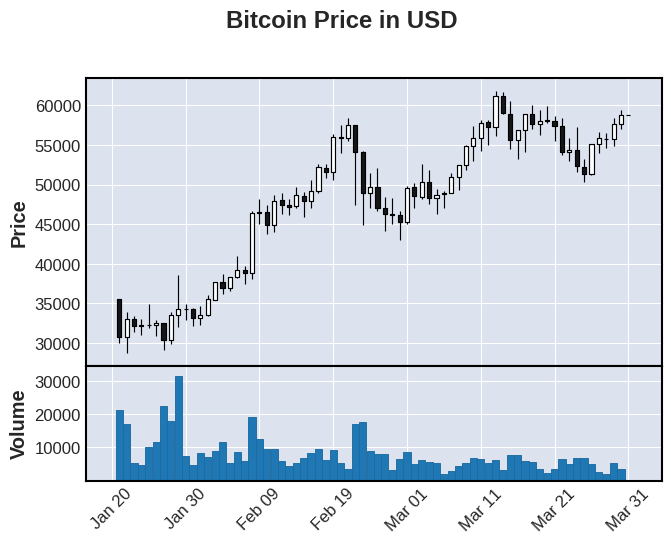

```python
import pandas as pd
import pandas_datareader.data as web
import datetime as dt
import matplotlib.pyplot as plt
import mplfinance as mpf
import matplotlib.dates as mdates
import seaborn as sb
plt.style.use('seaborn')
ticker = 'Bitcoin'
start = dt.date(2011, 12, 31)
day_df['Datetime'] = pd.to_datetime(day_df.index)
day_df.set_index('Datetime',inplace=True)
#Gathering the data
data = day_df
data["Volume"] = day_df['Volume_(BTC)']

mpf.plot(data.tail(70),type='candle',volume=True,show_nontrading=True,title="Bitcoin Price in USD")
```

The graph above shows the fluctuations in both price and volume over the course of approximately a 2 month-long period. From this we can see an almost inverse effect as the price of Bitcoin seems to rise as volume decreases and vice versa; however, we will need to look at more data over a larger timeframe as well as take into account some of our other features in order to determine if this is really the case.

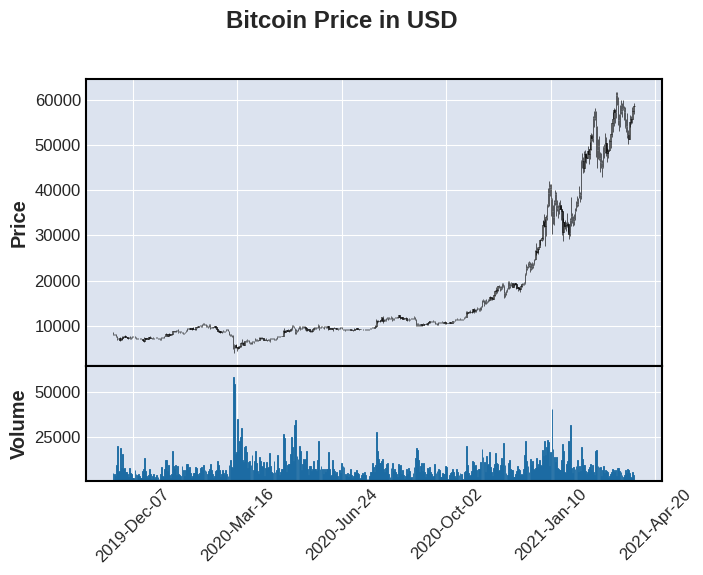

```python
plt.style.use('seaborn')
ticker = 'Bitcoin'
start = dt.date(2011, 12, 31)
day_df['Datetime'] = pd.to_datetime(day_df.index)
day_df.set_index('Datetime',inplace=True)
#Gathering the data
data = day_df
data["Volume"] = day_df['Volume_(BTC)']

mpf.plot(data.tail(500),type='candle',volume=True,show_nontrading=True,title="Bitcoin Price in USD")
```

### 3.1 Feature Distribution Visualization

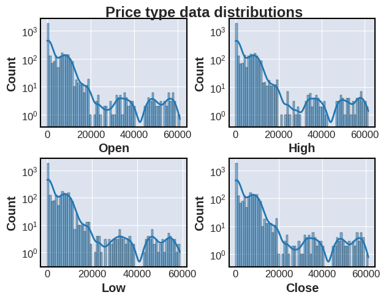

```python
f, axes = plt.subplots(2, 2)
f.suptitle("Price type data distributions")
f.tight_layout(pad=1.5)
sb.histplot(data=day_df, x='Open',kde=True,ax=axes[0,0])
sb.histplot(data=day_df, x='High',kde=True,ax=axes[0,1])
sb.histplot(data=day_df, x='Low',kde=True,ax=axes[1,0])
sb.histplot(data=day_df, x='Close',kde=True,ax=axes[1,1])
f.get_axes()[0].set_yscale('log')
f.get_axes()[1].set_yscale('log')
f.get_axes()[2].set_yscale('log')
f.get_axes()[3].set_yscale('log')
```

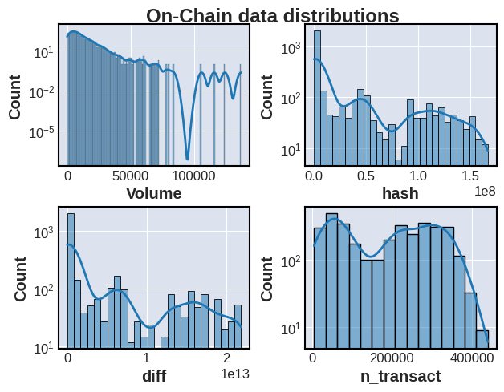

```python
f, axes = plt.subplots(2, 2)
f.suptitle("On-Chain data distributions")
f.tight_layout(pad=1.5)
sb.histplot(data=day_df, x='Volume',kde=True,ax=axes[0,0])
sb.histplot(data=day_df, x='hash',kde=True,ax=axes[0,1])
sb.histplot(data=day_df, x='diff',kde=True,ax=axes[1,0])
sb.histplot(data=day_df, x='n_transact',kde=True,ax=axes[1,1])
f.get_axes()[0].set_yscale('log')
f.get_axes()[1].set_yscale('log')
f.get_axes()[2].set_yscale('log')
f.get_axes()[3].set_yscale('log')
```

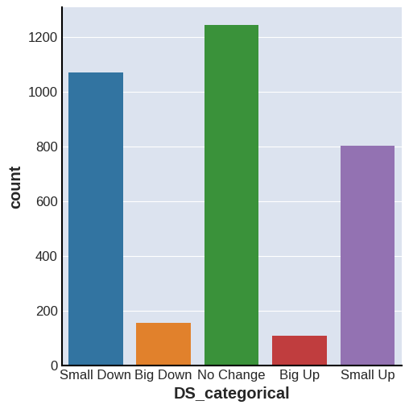

```python
import seaborn as sns

sns.catplot(x='DS_categorical', data=day_df_eliminated, kind='count');
```

### 3.2 Interesting Questions

After using a variety of different plots to dissect and explore our data, we came up with these 3 interesting questions:

```
1. How does price correlate with On-Chain statistics?
2. How does the change in price effect volume?
3. Does Hash rate correlate more with price or volume?
```

#### 3.2.1 How does price correlate with On-Chain statistics?

```
[Text(0, 0.5, 'Hash'), Text(0.5, 0, 'Day_Stats')]
```

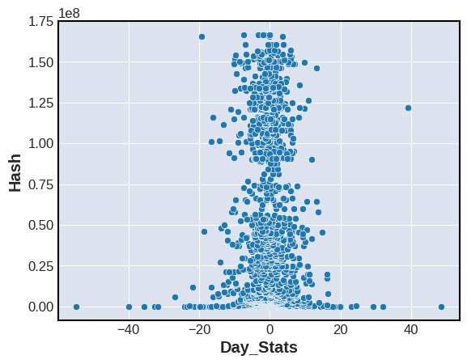

```python
plotting = sb.scatterplot(x=day_df['Day_Stats'].array, y=day_df['hash'].array, data=day_df)
plotting.set(xlabel='Day_Stats', ylabel='Hash')
```

```python
from numpy import  cov
from scipy.stats import pearsonr
from scipy.stats import spearmanr
covariance = np.cov(day_df['Day_Stats'],day_df['hash'])
Pearson_Corrilation = pearsonr(day_df['Day_Stats'],day_df['hash'])
Spearmans_Corrilation = spearmanr(day_df['Day_Stats'],day_df['hash'])
print("Covariance", covariance)
print("Pearson's Corrilation: ", Pearson_Corrilation)
print("Spearman's Corrilation: ",Spearmans_Corrilation )
```

```
Covariance [[2.14616759e+01 1.55043338e+06]
 [1.55043338e+06 2.02376492e+15]]
Pearson's Corrilation:  (0.007439457404648436, 0.6657594083549797)
Spearman's Corrilation:  SpearmanrResult(correlation=0.02101624788176082, pvalue=0.2222999333419905)
```

```
[Text(0, 0.5, 'Diff'), Text(0.5, 0, 'Day_Stats')]
```

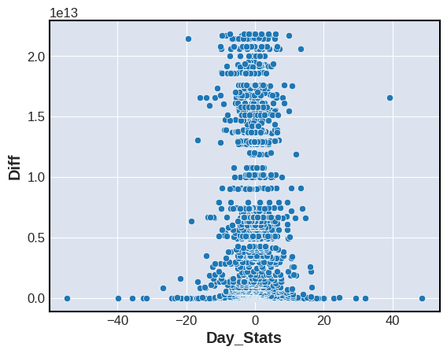

```python
plotting = sb.scatterplot(x=day_df['Day_Stats'].array, y=day_df['diff'].array, data=day_df)
plotting.set(xlabel='Day_Stats', ylabel='Diff')
```

```python
covariance = cov(day_df['Day_Stats'],day_df['diff'])
Pearson_Corrilation = pearsonr(day_df['Day_Stats'],day_df['diff'])
Spearmans_Corrilation = spearmanr(day_df['Day_Stats'],day_df['diff'])
print("Covariance", covariance)
print("Pearson's Corrilation: ", Pearson_Corrilation)
print("Spearman's Corrilation: ",Spearmans_Corrilation )
```

```
Covariance [[2.14616759e+01 2.18971281e+11]
 [2.18971281e+11 3.87312444e+25]]
Pearson's Corrilation:  (0.007594944721445229, 0.6592101480830865)
Spearman's Corrilation:  SpearmanrResult(correlation=0.021405678961566723, pvalue=0.2138475595372702)
```

```
[Text(0, 0.5, 'n_transact'), Text(0.5, 0, 'Day_Stats')]
```

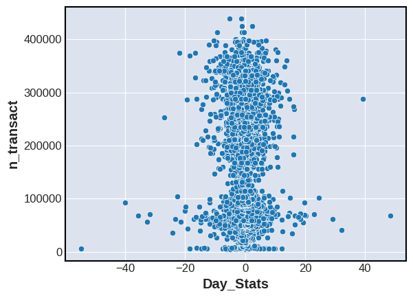

```python
plotting = sb.scatterplot(x=day_df['Day_Stats'].array, y=day_df['n_transact'].array, data=day_df)
plotting.set(xlabel='Day_Stats', ylabel='n_transact')
```

```python
covariance = cov(day_df['Day_Stats'],day_df['n_transact'])
Pearson_Corrilation = pearsonr(day_df['Day_Stats'],day_df['n_transact'])
Spearmans_Corrilation = spearmanr(day_df['Day_Stats'],day_df['n_transact'])
print("Covariance", covariance)
print("Pearson's Corrilation: ", Pearson_Corrilation)
print("Spearman's Corrilation: ",Spearmans_Corrilation )
```

```
Covariance [[2.14616759e+01 3.27745507e+03]
 [3.27745507e+03 1.32836517e+10]]
Pearson's Corrilation:  (0.006138272876684454, 0.7215261762080887)
Spearman's Corrilation:  SpearmanrResult(correlation=-0.007880731821773925, pvalue=0.6472407059548541)
```

In the 3 graphs above, we created a scatterplot comparing the overall day performance with the mining difficulty, overall computing power on the network, and number of transactions. In each of these graphs we found a pretty similar correlation which showed that none of this on-chain data seemed to have a noticeable effect on overall day performance as the majority of data is clumped near the center of the graph with the points that extend to each side not following any particular pattern.

#### 3.2.2 How does change in price effect volume?

```python
stats = np.abs(np.array(day_df['Day_Stats'].array))
```

```
[Text(0, 0.5, 'Volume'), Text(0.5, 0, 'Day_Stats')]
```

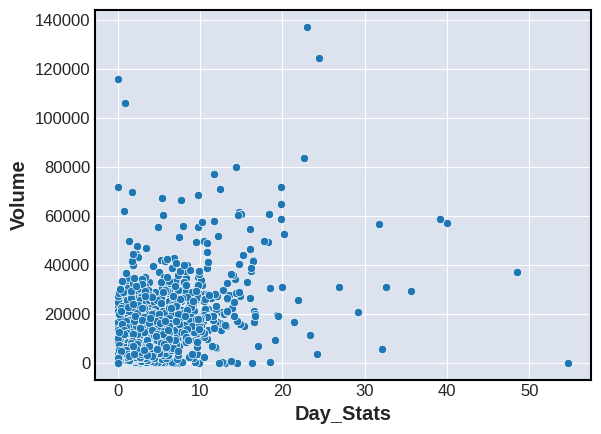

```python
plotting = sb.scatterplot(x=stats,y=day_df['Volume'].array,data=day_df)
plotting.set(xlabel='Day_Stats', ylabel='Volume')
```

```python
covariance = cov(day_df['Day_Stats'],day_df['Volume'])
Pearson_Corrilation = pearsonr(day_df['Day_Stats'],day_df['Volume'])
Spearmans_Corrilation = spearmanr(day_df['Day_Stats'],day_df['Volume'])
print("Covariance", covariance)
print("Pearson's Corrilation: ", Pearson_Corrilation)
print("Spearman's Corrilation: ",Spearmans_Corrilation )
```

```
Covariance [[2.14616759e+01 2.58166374e+03]
 [2.58166374e+03 1.01237888e+08]]
Pearson's Corrilation:  (0.05538553075925612, 0.001289033238747868)
Spearman's Corrilation:  SpearmanrResult(correlation=-0.01815157166234513, pvalue=0.29185959829746316)
```

#### 3.2.3 Does Hash rate correlate more with price or volume?

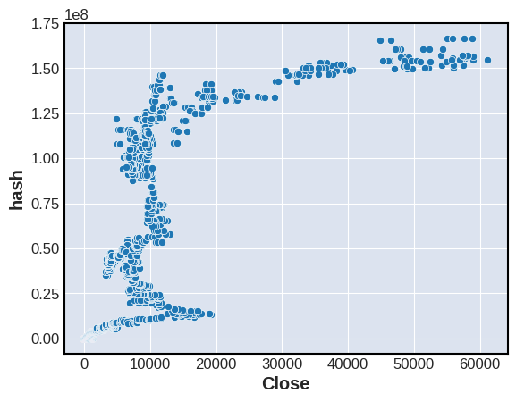

```python
sb.scatterplot(x=day_df['Close'], y=day_df['hash'], data=day_df)
```

```python
covariance = cov(day_df['Close'],day_df['hash'])
Pearson_Corrilation = pearsonr(day_df['Close'],day_df['hash'])
Spearmans_Corrilation = spearmanr(day_df['Close'],day_df['hash'])
print("Covariance", covariance)
print("Pearson's Corrilation: ", Pearson_Corrilation)
print("Spearman's Corrilation: ",Spearmans_Corrilation )
```

```
Covariance [[6.80239912e+07 2.87095839e+11]
 [2.87095839e+11 2.02376492e+15]]
Pearson's Corrilation:  (0.7737769896799512, 0.0)
Spearman's Corrilation:  SpearmanrResult(correlation=0.9341315355266718, pvalue=0.0)
```

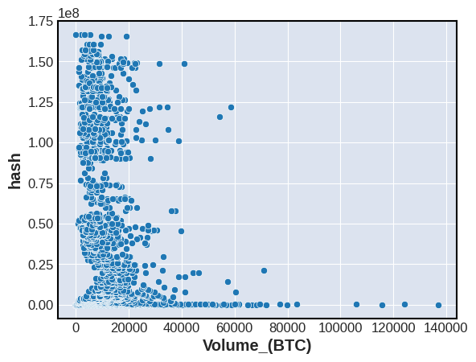

```python
sb.scatterplot(data=day_df, x=day_df['Volume_(BTC)'], y=day_df['hash'])
```

```python
covariance = cov(day_df['Volume_(BTC)'],day_df['hash'])
Pearson_Corrilation = pearsonr(day_df['Volume_(BTC)'],day_df['hash'])
Spearmans_Corrilation = spearmanr(day_df['Volume_(BTC)'],day_df['hash'])
print("Covariance", covariance)
print("Pearson's Corrilation: ", Pearson_Corrilation)
print("Spearman's Corrilation: ",Spearmans_Corrilation )
```

```
Covariance [[ 1.01237888e+08 -3.80365105e+10]
 [-3.80365105e+10  2.02376492e+15]]
Pearson's Corrilation:  (-0.08403285094690846, 1.0187447180970195e-06)
Spearman's Corrilation:  SpearmanrResult(correlation=0.15899371369296433, pvalue=1.5274917978675508e-20)
```

In the first graph, we plot the correlation between the hash rate or the amount of computing power used on a given day with the closing price of each day. From this, we can see a pretty strong correlation between these two variables as the hash rate seems to increase as the closing value of Bitcoin increased. This makes sense because Bitcoin is designed in such a way that the cost of mining an individual Bitcoin increases as market volume increases. As it becomes more difficult to mine bitcoin, the hash rate will increase and the price of bitcoin must rise in order to make ensure mining is still profitable when the marginal amount of bitcoin a miner makes over time is reduced.

In the second graph, we plotted the correlation between the hash rate and the overall volume of Bitcoin that is traded on a given day. From this it is fairly evident that there is not a major correlation between these two features as the majority of our data points exhist to the left of the graph with the volume staying relatively the same as hash rate goes up. Additionally, we can see that hash rate does not go up as volume goes up as we explore more of our data points to th right of the main cluster.

From this analysis, we can determine that hash rate has a much stronger correlation with price than it does with volume showing that price may be a great indicator for the network requirements of the system and vice versa. The Spearman's coefficient of the hash rate graph is nearly 1 showing a very high correlation while the coefficeint of the volume graph is less than .2.

## 4. UMAP Dimensionality Reduction

```python
day_df.columns
```

[output not shown]

```python
!pip install umap-learn[plot]
```

```python
import umap
import umap.plot
```

```python
mapper_w_price = umap.UMAP(n_neighbors=30,min_dist=0.01,metric='correlation').fit(day_df[['Open', 'High', 'Low', 'Close', 'Volume_(BTC)']].to_numpy())
```

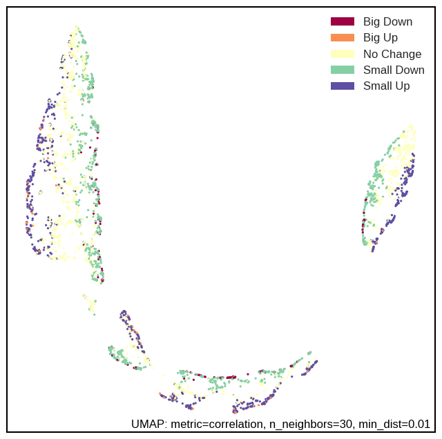

```python
umap.plot.points(mapper_w_price, labels=np.array(day_df['DS_categorical']))
```

```python
mapper_w_onchain = umap.UMAP(n_neighbors=10,min_dist=0.01,metric='correlation').fit(day_df[['Volume_(BTC)','n_transact', 'diff', 'hash']].to_numpy())
```

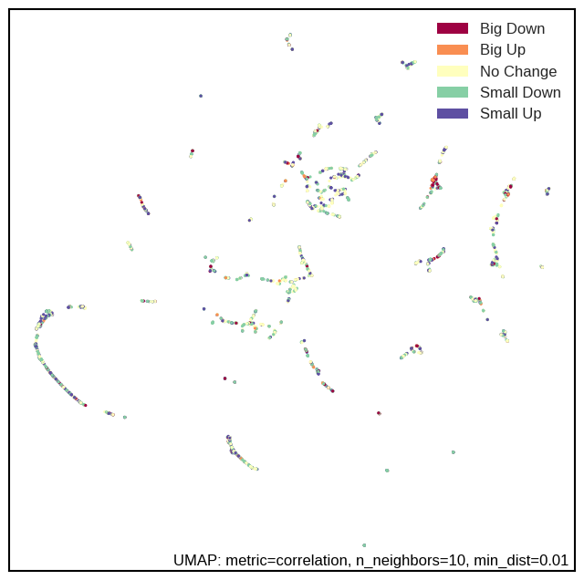

```python
umap.plot.points(mapper_w_onchain, labels=np.array(day_df['DS_categorical']))
```

UMAP utilizes graph theory to reduce a higher-dimensional graph to a lower dimensional graph. The graph concept plays an integral role by providing connection points in whatever dimensional space it is in. Connections are created by determining the number of neighbors allowed and the distance between neighbors. As connections are made, those connected are then mapped down to the required dimensions based on the space where the neighbors are. This then shows us that if our classes in our UMAP examples do not closely group, then dimensionality reduction can not prove useful because the information is not related enough to be condensed.

### References:

[1] Kaggle Bitcoin Historical Data Dataset. https://www.kaggle.com/mczielinski/bitcoin-historical-data

[2] Understanding UMAP. https://pair-code.github.io/understanding-umap/